# IDS702 Final Project: HomeCredit Default Risk Dataset

William Huang

November 28, 2018

## Project Objective

Home Credit Group, founded in Czech Republic a d headquartered in Netherlands, is a multinational non-bank financial company that provides consumer financial products, such as personal lending and credit card businesses. The company focuses primarily on people with no or little credit history. The project objective is to interpret how the information on the loan applications could affect the default risks of loan applicants.

#### Variable Descriptions

- **TARGET**: Target variable (1 - client with payment difficulties: he/she had late payment more than X days on at least one of the first Y installments of the loan in our sample, 0 - all other cases)
- **CODE_GENDER**: Gender of the client
- **NAME_CONTRACT_TYPE**: Identification if loan is cash or revolving
- **AMT_INCOME_TOTAL**: Income of the client
- **FLAG_OWN_CAR**: Flag if the client owns a car
- **FLAG_OWN_REALTY**: Flag if client owns a house or flat
- **CNT_CHILDREN**: Flag if client owns a house or flat
- **AMT_CREDIT**: Credit amount of the loan
- **AMT_ANNUITY**: Loan annuity
- **AMT_GOODS_PRICE**: For consumer loans it is the price of the goods for which the loan is given
- **NAME_TYPE_SUITE**: Who was accompanying client when he was applying for the loan
- **NAME_INCOME_TYPE**: Clients income type (businessman, working, maternity leave,…)
- **NAME_EDUCATION_TYPE**: Level of highest education the client achieved
- **NAME_FAMILY_STATUS**: Family status of the client
- **NAME_HOUSING_TYPE**: What is the housing situation of the client (renting, living with parents, …)
- **REGION_POPULATION_RELATIVE**: Normalized population of region where client lives (higher number means the client lives in more populated region)
- **DAYS_BIRTH**: Client’s age in days at the time of application
- **DAYS_EMPLOYED**: How many days before the application the person started current employment
- **OWN_CAR_AGE**: Age of client’s car
- **OCCUPATION_TYPE**: What kind of occupation does the client have
- **CNT_FAM_MEMBERS**: How many family members does client have
- **ORGANIZATION_TYPE**: Type of organization where client works
- **AMT_REQ_CREDIT_BUREAU_HOUR**: Number of enquiries to Credit Bureau about the client one hour before application
- **AMT_REQ_CREDIT_BUREAU_DAY**: Number of enquiries to Credit Bureau about the client one day before application (excluding one hour before application)
- **AMT_REQ_CREDIT_BUREAU_WEEK**: Number of enquiries to Credit Bureau about the client one week before application (excluding one day before application)
- **AMT_REQ_CREDIT_BUREAU_MON**: Number of enquiries to Credit Bureau about the client one month before application (excluding one week before application)
- **AMT_REQ_CREDIT_BUREAU_QRT**: Number of enquiries to Credit Bureau about the client 3 month before application (excluding one month before application)
- **AMT_REQ_CREDIT_BUREAU_YEAR**: Number of enquiries to Credit Bureau about the client one day year (excluding last 3 months before application)

### Load Data and Data Pre-processing

As the original dataset contains over 200 independent variables, I picked 23 variables for further analysis and interpretations based on my interests and previous experience in this industry. Besides, I also combined the following 6 variables together to improve the interpretability of my model: `AMT_REQ_CREDIT_BUREAU_HOUR`, `AMT_REQ_CREDIT_BUREAU_DAY`, `AMT_REQ_CREDIT_BUREAU_WEEK`, `AMT_REQ_CREDIT_BUREAU_MON`, `AMT_REQ_CREDIT_BUREAU_QRT`, `AMT_REQ_CREDIT_BUREAU_YEAR`. These variables represent the number of enquiries to Credit Bureau about the client one hour, one day(excluding one hour before), one week(excluding one day before), one month(excluding one week before), one quarter(excluding one month before) and one year(excluding one quarter before) before application. As my goal is to construct an interpretation model, instead of a predictive model, the integration of these variables could enhance the interpretability of the model substantially. On the other hand, if I intended to build a predictive model, I should have kept them as 6 different variables.

```r
library(mice)
library(dplyr)
library(tidyverse)
library(pROC)
library(arm)
#setwd("/Users/wh132/Desktop")
setwd("/Users/Macintosh/Desktop")
application_data <- read.csv("application_train.csv")
```

```r
#select interested variables
application_data_selected <- subset(application_data, select = c("TARGET","CODE_GENDER","NAME_CONTRACT_TYPE","AMT_INCOME_TOTAL","FLAG_OWN_CAR","FLAG_OWN_REALTY","CNT_CHILDREN","AMT_CREDIT", "AMT_ANNUITY", "AMT_GOODS_PRICE", "NAME_TYPE_SUITE","NAME_INCOME_TYPE","NAME_EDUCATION_TYPE","NAME_FAMILY_STATUS","NAME_HOUSING_TYPE","REGION_POPULATION_RELATIVE","DAYS_BIRTH","DAYS_EMPLOYED","OWN_CAR_AGE","OCCUPATION_TYPE","CNT_FAM_MEMBERS","ORGANIZATION_TYPE","AMT_REQ_CREDIT_BUREAU_HOUR","AMT_REQ_CREDIT_BUREAU_DAY","AMT_REQ_CREDIT_BUREAU_WEEK","AMT_REQ_CREDIT_BUREAU_MON","AMT_REQ_CREDIT_BUREAU_QRT","AMT_REQ_CREDIT_BUREAU_YEAR"))

#combine all the AMT_REQ_CREDIT_BUREAU variables together to compute the aggregated number of enquiries to Credit Bureau about the client one year before the application
application_data_selected$AMR_REQ_CREDIT_BUREAU_SUM <- application_data_selected$AMT_REQ_CREDIT_BUREAU_HOUR+application_data_selected$AMT_REQ_CREDIT_BUREAU_DAY+application_data_selected$AMT_REQ_CREDIT_BUREAU_MON+application_data_selected$AMT_REQ_CREDIT_BUREAU_QRT+application_data_selected$AMT_REQ_CREDIT_BUREAU_WEEK+application_data_selected$AMT_REQ_CREDIT_BUREAU_YEAR

#Drop AMT_REQ_CREDIT_BUREAU_HOUR, DAY, WEEK, MON, QRT, YEAR
application_data_selected <- application_data_selected %>%
    dplyr::select(-(AMT_REQ_CREDIT_BUREAU_HOUR)) %>%
    dplyr::select(-(AMT_REQ_CREDIT_BUREAU_DAY)) %>%
    dplyr::select(-(AMT_REQ_CREDIT_BUREAU_WEEK)) %>%
    dplyr::select(-(AMT_REQ_CREDIT_BUREAU_MON)) %>%
    dplyr::select(-(AMT_REQ_CREDIT_BUREAU_QRT)) %>%
    dplyr::select(-(AMT_REQ_CREDIT_BUREAU_YEAR))
```

- 1. (`AMT_CREDIT`, `AMT_GOODS_PRICE`), corr = 0.987 `AMT_GOODS_PRICE` represents the goods price of good that client asked for on the previous application. `AMT_CREDIT` represents the final credit amount on the previous application. Through the definitions of these two variables, it’s clear that we could drop one of the variables.
- 2. (`CNT_FAM_MEMBERS`, `CNT_CHILDREN`), corr = 0.914 `CNT_FAM_mEMBERS` represents how many family members clients have `CNT_CHILDREN` represents how many children clients have Through the definitions of these two variables, it’s clear that we should drop one of the variables.

```r
#check collinearity
num <- unlist(lapply(application_data_selected, is.numeric))
cor(cc(application_data_selected[,num]), use = "pair")
```

```
##                                  TARGET AMT_INCOME_TOTAL CNT_CHILDREN
## TARGET                      1.000000000     -0.022374536  0.005679723
## AMT_INCOME_TOTAL           -0.022374536      1.000000000  0.006490665
## CNT_CHILDREN                0.005679723      0.006490665  1.000000000
## AMT_CREDIT                 -0.035478230      0.324854819 -0.021083017
## AMT_ANNUITY                -0.015778897      0.411376003 -0.001362760
## AMT_GOODS_PRICE            -0.044389541      0.332695445 -0.024611028
## REGION_POPULATION_RELATIVE -0.036110371      0.167362370 -0.032117581
## DAYS_BIRTH                  0.054896182      0.015586880  0.279672331
## DAYS_EMPLOYED              -0.028323415     -0.103847372 -0.183114593
## OWN_CAR_AGE                 0.037232346     -0.132171880  0.008950126
## CNT_FAM_MEMBERS            -0.001250596     -0.001726251  0.914413945
## AMR_REQ_CREDIT_BUREAU_SUM   0.019143211      0.035277693 -0.029676739
##                             AMT_CREDIT AMT_ANNUITY AMT_GOODS_PRICE
## TARGET                     -0.03547823 -0.01577890     -0.04438954
## AMT_INCOME_TOTAL            0.32485482  0.41137600      0.33269544
## CNT_CHILDREN               -0.02108302 -0.00136276     -0.02461103
## AMT_CREDIT                  1.00000000  0.74634289      0.98718062
## AMT_ANNUITY                 0.74634289  1.00000000      0.75161981
## AMT_GOODS_PRICE             0.98718062  0.75161981      1.00000000
## REGION_POPULATION_RELATIVE  0.09204365  0.11265566      0.09609678
## DAYS_BIRTH                 -0.11694218 -0.05319892     -0.11380798
## DAYS_EMPLOYED              -0.01937100 -0.05245937     -0.01794351
## OWN_CAR_AGE                -0.09280021 -0.09619776     -0.10185298
## CNT_FAM_MEMBERS             0.02020290  0.03046515      0.01779781
## AMR_REQ_CREDIT_BUREAU_SUM  -0.01731215  0.01144510     -0.01839987
##                            REGION_POPULATION_RELATIVE   DAYS_BIRTH
## TARGET                                   -0.036110371  0.054896182
## AMT_INCOME_TOTAL                          0.167362370  0.015586880
## CNT_CHILDREN                             -0.032117581  0.279672331
## AMT_CREDIT                                0.092043647 -0.116942177
## AMT_ANNUITY                               0.112655663 -0.053198919
## AMT_GOODS_PRICE                           0.096096778 -0.113807976
## REGION_POPULATION_RELATIVE                1.000000000 -0.038847969
## DAYS_BIRTH                               -0.038847969  1.000000000
## DAYS_EMPLOYED                             0.002191339 -0.508824142
## OWN_CAR_AGE                              -0.081436107  0.001110481
## CNT_FAM_MEMBERS                          -0.034209956  0.197954108
## AMR_REQ_CREDIT_BUREAU_SUM                 0.025584835 -0.032038595
##                            DAYS_EMPLOYED  OWN_CAR_AGE CNT_FAM_MEMBERS
```

[output cut: 10 more lines]

```
## CNT_FAM_MEMBERS             -0.152888423 -0.014499077     1.000000000
## AMR_REQ_CREDIT_BUREAU_SUM    0.007042087 -0.026658773    -0.018385506
##                            AMR_REQ_CREDIT_BUREAU_SUM
## TARGET                                   0.019143211
## AMT_INCOME_TOTAL                         0.035277693
## CNT_CHILDREN                            -0.029676739
## AMT_CREDIT                              -0.017312145
## AMT_ANNUITY                              0.011445101
## AMT_GOODS_PRICE                         -0.018399870
## REGION_POPULATION_RELATIVE               0.025584835
## DAYS_BIRTH                              -0.032038595
## DAYS_EMPLOYED                            0.007042087
## OWN_CAR_AGE                             -0.026658773
## CNT_FAM_MEMBERS                         -0.018385506
## AMR_REQ_CREDIT_BUREAU_SUM                1.000000000
```

```r
application_data_selected <- application_data_selected %>%
    dplyr::select(-(AMT_GOODS_PRICE)) %>%
    dplyr::select(-(CNT_CHILDREN))
```

Here we should factorize `CNT_FAM_MEMBERS`, representing how many family members the loan applicant has, and `AMT_REQ_CREDIT_BUREAU_SUM`, representing number of enquiries to Credit Bureau about the client one year before submitting his loan application, as both variables are more like categorical rather than continuous based on their definitions.

```r
#factorize CNT_FAM_MEMBERS, AMR_REQ_CREDIT_BUREAU_SUM
application_data_selected$CNT_FAM_MEMBERS <- as.factor(application_data_selected$CNT_FAM_MEMBERS)
application_data_selected$AMR_REQ_CREDIT_BUREAU_SUM <- as.factor(application_data_selected$AMR_REQ_CREDIT_BUREAU_SUM)
```

As the dataset is extremely large and my computer’s computing power doesn’t support this size of computations. Therefore, I decided to randomly select 10,000 observations to run further analysis. Due to the random selection process, the random selection process should be able to represent the population. The summary tables for original dataset and the dataset after my random selection process in the Data Description section below also support this claim.

```r
set.seed(100)
application_data_sam <- application_data_selected[sample(nrow(application_data_selected), 10000), ]
summary(application_data_sam)
```

```
##      TARGET       CODE_GENDER       NAME_CONTRACT_TYPE AMT_INCOME_TOTAL
##  Min.   :0.0000   F  :6556    Cash loans     :9025     Min.   :  25650
##  1st Qu.:0.0000   M  :3444    Revolving loans: 975     1st Qu.: 112500
##  Median :0.0000   XNA:   0                             Median : 148500
##  Mean   :0.0829                                        Mean   : 167765
##  3rd Qu.:0.0000                                        3rd Qu.: 202500
##  Max.   :1.0000                                        Max.   :2250000
##
##  FLAG_OWN_CAR FLAG_OWN_REALTY   AMT_CREDIT       AMT_ANNUITY
##  N:6540       N:3070          Min.   :  45000   Min.   :  2844
##  Y:3460       Y:6930          1st Qu.: 270000   1st Qu.: 16574
##                               Median : 521280   Median : 25047
##                               Mean   : 599379   Mean   : 27049
##                               3rd Qu.: 808650   3rd Qu.: 34533
##                               Max.   :2961000   Max.   :133848
##
##         NAME_TYPE_SUITE             NAME_INCOME_TYPE
##  Unaccompanied  :8115   Working             :5123
##  Family         :1278   Commercial associate:2335
##  Spouse, partner: 374   Pensioner           :1804
##  Children       : 118   State servant       : 735
##  Other_B        :  50   Businessman         :   1
##                 :  39   Student             :   1
##  (Other)        :  26   (Other)             :   1
##                     NAME_EDUCATION_TYPE            NAME_FAMILY_STATUS
##  Academic degree              :   5     Civil marriage      :1036
##  Higher education             :2414     Married             :6320
##  Incomplete higher            : 305     Separated           : 663
##  Lower secondary              : 114     Single / not married:1469
##  Secondary / secondary special:7162     Unknown             :   0
##                                         Widow               : 512
##
##            NAME_HOUSING_TYPE REGION_POPULATION_RELATIVE   DAYS_BIRTH
##  Co-op apartment    :  45    Min.   :0.000938           Min.   :-25186
##  House / apartment  :8863    1st Qu.:0.010006           1st Qu.:-19688
##  Municipal apartment: 356    Median :0.018850           Median :-15820
##  Office apartment   :  80    Mean   :0.020710           Mean   :-16047
##  Rented apartment   : 179    3rd Qu.:0.028663           3rd Qu.:-12469
##  With parents       : 477    Max.   :0.072508           Max.   : -7721
##
##  DAYS_EMPLOYED       OWN_CAR_AGE       OCCUPATION_TYPE CNT_FAM_MEMBERS
##  Min.   :-17546.0   Min.   : 0.00              :3162   2      :5197
##  1st Qu.: -2729.0   1st Qu.: 5.00   Laborers   :1793   1      :2186
##  Median : -1181.5   Median : 9.00   Sales staff:1041   3      :1686
##  Mean   : 63952.6   Mean   :11.97   Core staff : 878   4      : 814
##  3rd Qu.:  -283.5   3rd Qu.:15.00   Managers   : 667   5      : 101
##  Max.   :365243.0   Max.   :65.00   Drivers    : 623   6      :  11
##                     NA's   :6540    (Other)    :1836   (Other):   5
##               ORGANIZATION_TYPE AMR_REQ_CREDIT_BUREAU_SUM
##  Business Entity Type 3:2229    1      :1719
##  XNA                   :1804    2      :1696
##  Self-employed         :1263    0      :1672
##  Other                 : 529    3      :1304
##  Business Entity Type 2: 354    4      : 906
##  Government            : 350    (Other):1376
##  (Other)               :3471    NA's   :1327
```

## Data Description

Through the two tables below, we can see that the distributions of each variable in the original and new datasets are fairly similar. Besides, we also have some missing values and should consider missing value imputations.

```r
summary(application_data_selected) #original datasets with selected variables
```

```
##      TARGET        CODE_GENDER        NAME_CONTRACT_TYPE
##  Min.   :0.00000   F  :202448   Cash loans     :278232
##  1st Qu.:0.00000   M  :105059   Revolving loans: 29279
##  Median :0.00000   XNA:     4
##  Mean   :0.08073
##  3rd Qu.:0.00000
##  Max.   :1.00000
##
##  AMT_INCOME_TOTAL    FLAG_OWN_CAR FLAG_OWN_REALTY   AMT_CREDIT
##  Min.   :    25650   N:202924     N: 94199        Min.   :  45000
##  1st Qu.:   112500   Y:104587     Y:213312        1st Qu.: 270000
##  Median :   147150                                Median : 513531
##  Mean   :   168798                                Mean   : 599026
##  3rd Qu.:   202500                                3rd Qu.: 808650
##  Max.   :117000000                                Max.   :4050000
##
##   AMT_ANNUITY            NAME_TYPE_SUITE               NAME_INCOME_TYPE
##  Min.   :  1616   Unaccompanied  :248526   Working             :158774
##  1st Qu.: 16524   Family         : 40149   Commercial associate: 71617
##  Median : 24903   Spouse, partner: 11370   Pensioner           : 55362
##  Mean   : 27109   Children       :  3267   State servant       : 21703
##  3rd Qu.: 34596   Other_B        :  1770   Unemployed          :    22
##  Max.   :258026                  :  1292   Student             :    18
##  NA's   :12       (Other)        :  1137   (Other)             :    15
##                     NAME_EDUCATION_TYPE            NAME_FAMILY_STATUS
##  Academic degree              :   164   Civil marriage      : 29775
##  Higher education             : 74863   Married             :196432
##  Incomplete higher            : 10277   Separated           : 19770
##  Lower secondary              :  3816   Single / not married: 45444
##  Secondary / secondary special:218391   Unknown             :     2
##                                         Widow               : 16088
##
##            NAME_HOUSING_TYPE  REGION_POPULATION_RELATIVE   DAYS_BIRTH
##  Co-op apartment    :  1122   Min.   :0.00029            Min.   :-25229
##  House / apartment  :272868   1st Qu.:0.01001            1st Qu.:-19682
##  Municipal apartment: 11183   Median :0.01885            Median :-15750
##  Office apartment   :  2617   Mean   :0.02087            Mean   :-16037
##  Rented apartment   :  4881   3rd Qu.:0.02866            3rd Qu.:-12413
##  With parents       : 14840   Max.   :0.07251            Max.   : -7489
##
##  DAYS_EMPLOYED     OWN_CAR_AGE        OCCUPATION_TYPE  CNT_FAM_MEMBERS
##  Min.   :-17912   Min.   : 0.00               :96391   2      :158357
##  1st Qu.: -2760   1st Qu.: 5.00    Laborers   :55186   1      : 67847
##  Median : -1213   Median : 9.00    Sales staff:32102   3      : 52601
##  Mean   : 63815   Mean   :12.06    Core staff :27570   4      : 24697
##  3rd Qu.:  -289   3rd Qu.:15.00    Managers   :21371   5      :  3478
##  Max.   :365243   Max.   :91.00    Drivers    :18603   (Other):   529
##                   NA's   :202929   (Other)    :56288   NA's   :     2
##               ORGANIZATION_TYPE  AMR_REQ_CREDIT_BUREAU_SUM
##  Business Entity Type 3: 67992   1      :53914
##  XNA                   : 55374   2      :51559
##  Self-employed         : 38412   0      :50911
##  Other                 : 16683   3      :39380
##  Medicine              : 11193   4      :27241
##  Business Entity Type 2: 10553   (Other):42987
##  (Other)               :107304   NA's   :41519
```

```r
summary(application_data_sam) #the dataset after the random selection process
```

```
##      TARGET       CODE_GENDER       NAME_CONTRACT_TYPE AMT_INCOME_TOTAL
##  Min.   :0.0000   F  :6556    Cash loans     :9025     Min.   :  25650
##  1st Qu.:0.0000   M  :3444    Revolving loans: 975     1st Qu.: 112500
##  Median :0.0000   XNA:   0                             Median : 148500
##  Mean   :0.0829                                        Mean   : 167765
##  3rd Qu.:0.0000                                        3rd Qu.: 202500
##  Max.   :1.0000                                        Max.   :2250000
##
##  FLAG_OWN_CAR FLAG_OWN_REALTY   AMT_CREDIT       AMT_ANNUITY
##  N:6540       N:3070          Min.   :  45000   Min.   :  2844
##  Y:3460       Y:6930          1st Qu.: 270000   1st Qu.: 16574
##                               Median : 521280   Median : 25047
##                               Mean   : 599379   Mean   : 27049
##                               3rd Qu.: 808650   3rd Qu.: 34533
##                               Max.   :2961000   Max.   :133848
##
##         NAME_TYPE_SUITE             NAME_INCOME_TYPE
##  Unaccompanied  :8115   Working             :5123
##  Family         :1278   Commercial associate:2335
##  Spouse, partner: 374   Pensioner           :1804
##  Children       : 118   State servant       : 735
##  Other_B        :  50   Businessman         :   1
##                 :  39   Student             :   1
##  (Other)        :  26   (Other)             :   1
##                     NAME_EDUCATION_TYPE            NAME_FAMILY_STATUS
##  Academic degree              :   5     Civil marriage      :1036
##  Higher education             :2414     Married             :6320
##  Incomplete higher            : 305     Separated           : 663
##  Lower secondary              : 114     Single / not married:1469
##  Secondary / secondary special:7162     Unknown             :   0
##                                         Widow               : 512
##
##            NAME_HOUSING_TYPE REGION_POPULATION_RELATIVE   DAYS_BIRTH
##  Co-op apartment    :  45    Min.   :0.000938           Min.   :-25186
##  House / apartment  :8863    1st Qu.:0.010006           1st Qu.:-19688
##  Municipal apartment: 356    Median :0.018850           Median :-15820
##  Office apartment   :  80    Mean   :0.020710           Mean   :-16047
##  Rented apartment   : 179    3rd Qu.:0.028663           3rd Qu.:-12469
##  With parents       : 477    Max.   :0.072508           Max.   : -7721
##
##  DAYS_EMPLOYED       OWN_CAR_AGE       OCCUPATION_TYPE CNT_FAM_MEMBERS
##  Min.   :-17546.0   Min.   : 0.00              :3162   2      :5197
##  1st Qu.: -2729.0   1st Qu.: 5.00   Laborers   :1793   1      :2186
##  Median : -1181.5   Median : 9.00   Sales staff:1041   3      :1686
##  Mean   : 63952.6   Mean   :11.97   Core staff : 878   4      : 814
##  3rd Qu.:  -283.5   3rd Qu.:15.00   Managers   : 667   5      : 101
##  Max.   :365243.0   Max.   :65.00   Drivers    : 623   6      :  11
##                     NA's   :6540    (Other)    :1836   (Other):   5
##               ORGANIZATION_TYPE AMR_REQ_CREDIT_BUREAU_SUM
##  Business Entity Type 3:2229    1      :1719
##  XNA                   :1804    2      :1696
##  Self-employed         :1263    0      :1672
##  Other                 : 529    3      :1304
##  Business Entity Type 2: 354    4      : 906
##  Government            : 350    (Other):1376
##  (Other)               :3471    NA's   :1327
```

## Missing values imputation

`OWN_CAR_AGE` and `AMR_REQ_CREDOT_BUREAU_SUM` are the two columns that contain missing values in the dataset. I used the mice package to conduct missing value imputation to generate complete datasets. For the imputation method, I chose cart, instead of the default method. I have tried to use the default method to impute missing values; however, it returned the following error `"system is computationally singular"`. The cause of the problem here could probably be the large number of unbalanced factor variables, such as `NAME_CONTRACT_TYPE`, `NAME_TYPE_SUITE` and `NAME_EDUCATION_TYPE`, in the dataset. When these variables are turned into dummy variables, there’s a high probability that one column is a linear combination of another. As the default imputation methods are parametric, which involve linear regression, this would result in a X matrix that cannot be inverted. Therefore, I considered to change the imputation method to Classification and Regression Trees (CART) that is not stochastic and non-parametric, which require no X matrix inversion. (Reference: [links](https://bit.ly/2QdvVzR))

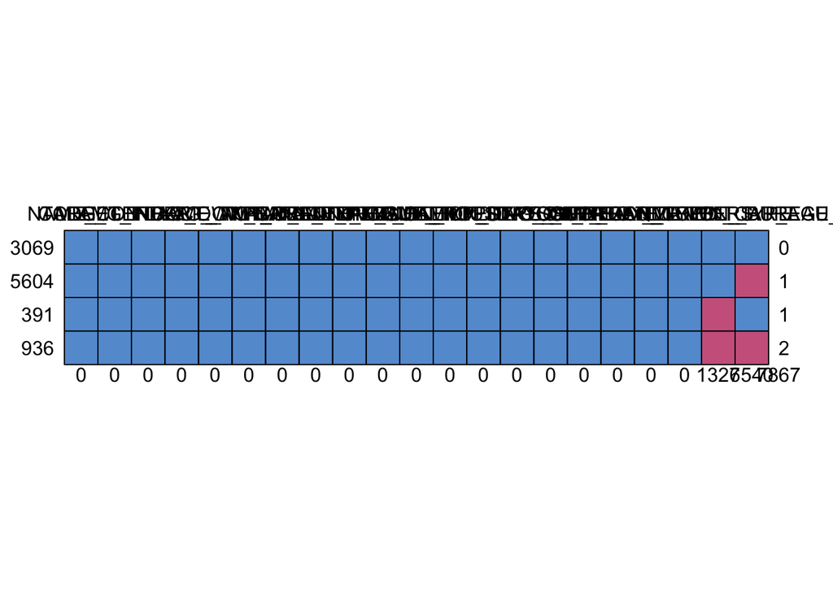

```
##      TARGET CODE_GENDER NAME_CONTRACT_TYPE AMT_INCOME_TOTAL FLAG_OWN_CAR
## 3069      1           1                  1                1            1
## 5604      1           1                  1                1            1
## 391       1           1                  1                1            1
## 936       1           1                  1                1            1
##           0           0                  0                0            0
##      FLAG_OWN_REALTY AMT_CREDIT AMT_ANNUITY NAME_TYPE_SUITE
## 3069               1          1           1               1
## 5604               1          1           1               1
## 391                1          1           1               1
## 936                1          1           1               1
##                    0          0           0               0
##      NAME_INCOME_TYPE NAME_EDUCATION_TYPE NAME_FAMILY_STATUS
## 3069                1                   1                  1
## 5604                1                   1                  1
```

[output cut: 21 more lines]

```r
#check pattern
md.pattern(application_data_sam)
```

```r
application_MI <- mice(application_data_sam, m = 10, method = "cart", seed = 8)
```

## Imputation Model Diagnostics

Based on the charts below, no problematic pattern with the imputations.

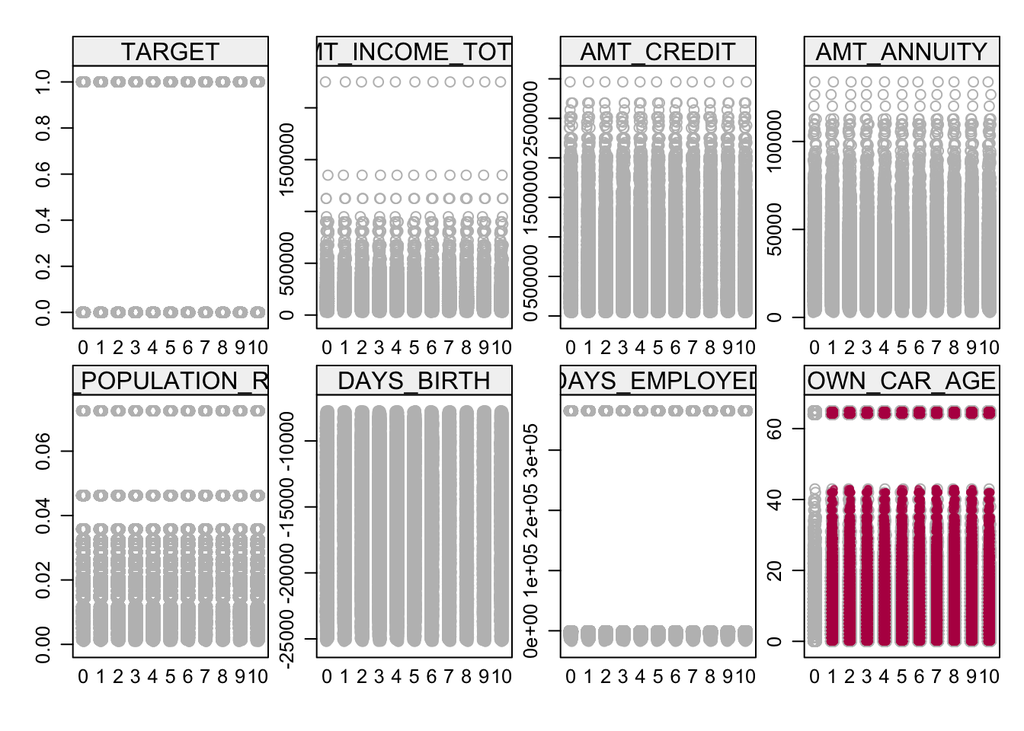

```r
stripplot(application_MI, col=c("grey",mdc(2)),pch=c(1,20))
```

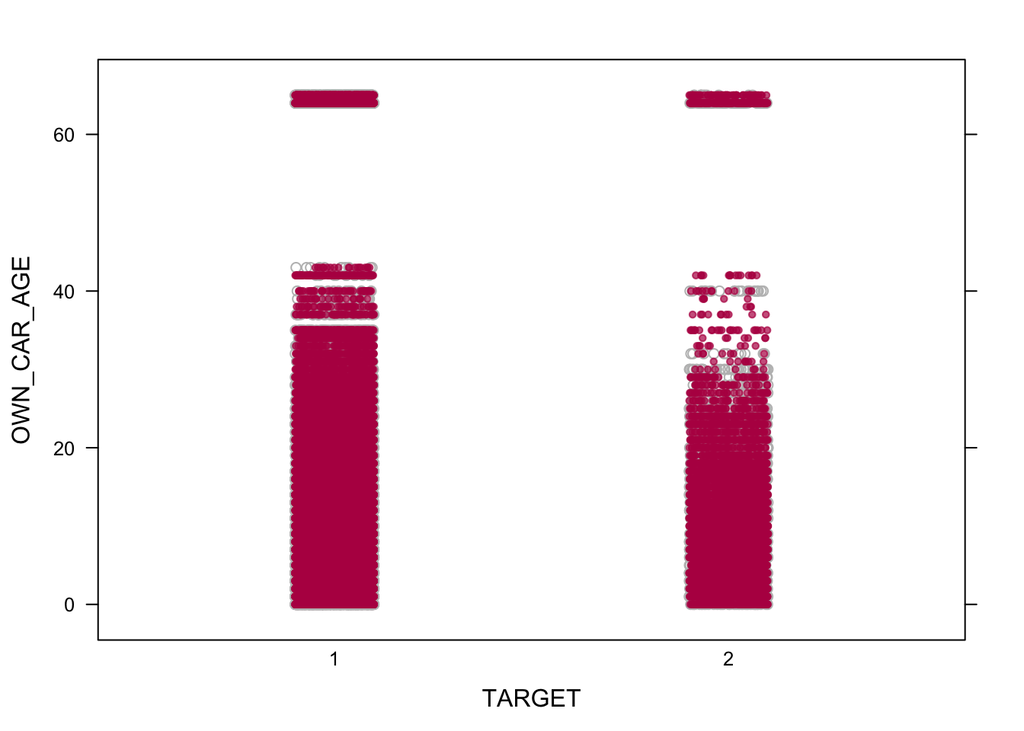

```r
stripplot(application_MI, OWN_CAR_AGE~TARGET, col=c("grey",mdc(2)),pch=c(1,20), xlab = 'TARGET', ylab = "OWN_CAR_AGE")
```

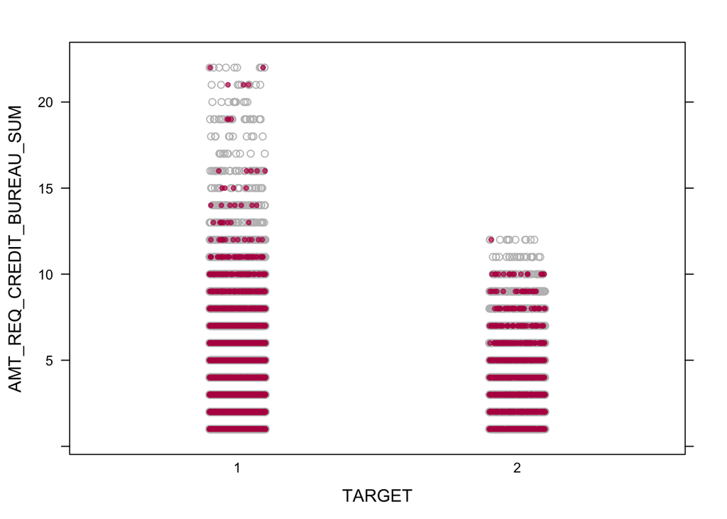

```r
stripplot(application_MI, AMR_REQ_CREDIT_BUREAU_SUM~TARGET, col=c("grey",mdc(2)),pch=c(1,20), xlab = 'TARGET', ylab = "AMT_REQ_CREDIT_BUREAU_SUM")
```

## Posterior Predictive Check on Two Complete Datasets

Both the histogram and boxplots look similiar for replica and complete datasets; therefore, there is no evidence suggests that imputation models are poorly specified for what I want to do.

```r
application_ppcheck <- rbind(application_data_sam, application_data_sam)
application_ppcheck[10001:20000, apply(is.na(application_data_sam), any, MARGIN = 2)] <- NA
application_ppcheck_MI <- mice(application_ppcheck, m = 10, method = "cart", seed = 12)
d1ppcheck <- mice::complete(application_ppcheck_MI, 1)
d2ppcheck <- mice::complete(application_ppcheck_MI, 2)
```

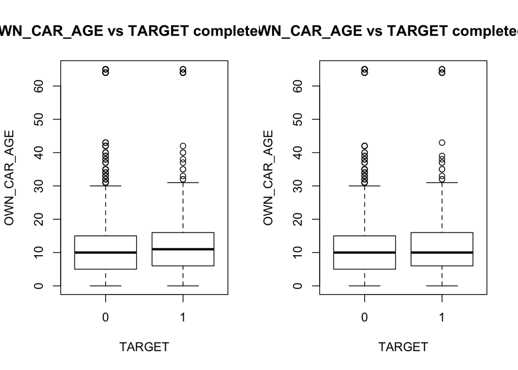

```r
#dataset1
par(mfrow = c(1,2))
boxplot(d1ppcheck$OWN_CAR_AGE[1:10000]~d1ppcheck$TARGET[1:10000], ylab="OWN_CAR_AGE", xlab="TARGET", main = "OWN_CAR_AGE vs TARGET completed data")
boxplot(d1ppcheck$OWN_CAR_AGE[10001:20000]~d1ppcheck$TARGET[10001:20000], ylab="OWN_CAR_AGE", xlab="TARGET", main = "OWN_CAR_AGE vs TARGET completed data")
```

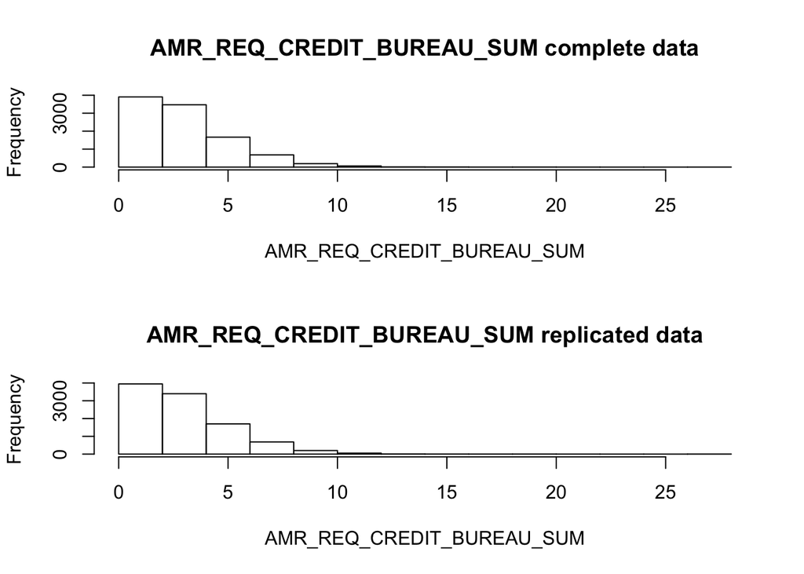

```r
par(mfrow = c(2,1))
hist(as.numeric(d1ppcheck$AMR_REQ_CREDIT_BUREAU_SUM[1:10000]), xlab="AMR_REQ_CREDIT_BUREAU_SUM", main = "AMR_REQ_CREDIT_BUREAU_SUM complete data")
hist(as.numeric(d1ppcheck$AMR_REQ_CREDIT_BUREAU_SUM[10001:20000]), xlab="AMR_REQ_CREDIT_BUREAU_SUM", main = "AMR_REQ_CREDIT_BUREAU_SUM replicated data")
```

## Exploratory Data Analysis

###### For categorical variables:

```r
#Dataset 1
cd1 <- mice::complete(application_MI, 1)
tapply(cd1$TARGET, cd1$CODE_GENDER, mean)
```

```
##          F          M        XNA
## 0.06696156 0.11324042         NA
```

```r
tapply(cd1$TARGET, cd1$NAME_CONTRACT_TYPE, mean)
```

```
##      Cash loans Revolving loans
##      0.08698061      0.04512821
```

```r
tapply(cd1$TARGET, cd1$FLAG_OWN_CAR, mean)
```

```
##          N          Y
## 0.08837920 0.07254335
```

```r
tapply(cd1$TARGET, cd1$FLAG_OWN_REALTY, mean)
```

```
##          N          Y
## 0.08534202 0.08181818
```

```r
tapply(cd1$TARGET, cd1$NAME_TYPE_SUITE, mean)
```

```
##                        Children          Family Group of people
##      0.07692308      0.05084746      0.08607199      0.00000000
##         Other_A         Other_B Spouse, partner   Unaccompanied
##      0.04761905      0.06000000      0.09090909      0.08280961
```

```r
tapply(cd1$TARGET, cd1$NAME_INCOME_TYPE, mean)
```

```
##          Businessman Commercial associate      Maternity leave
##           0.00000000           0.07366167                   NA
##            Pensioner        State servant              Student
##           0.05266075           0.04353741           0.00000000
##           Unemployed              Working
##           0.00000000           0.10345501
```

```r
tapply(cd1$TARGET, cd1$NAME_EDUCATION_TYPE, mean)
```

```
##               Academic degree              Higher education
##                    0.00000000                    0.05675228
##             Incomplete higher               Lower secondary
##                    0.10163934                    0.12280702
## Secondary / secondary special
##                    0.09033789
```

```r
tapply(cd1$TARGET, cd1$NAME_FAMILY_STATUS, mean)
```

```
##       Civil marriage              Married            Separated
##           0.09266409           0.07721519           0.07843137
## Single / not married              Unknown                Widow
##           0.10619469                   NA           0.07226562
```

```r
tapply(cd1$TARGET, cd1$NAME_HOUSING_TYPE, mean)
```

```
##     Co-op apartment   House / apartment Municipal apartment
##          0.08888889          0.08055963          0.07022472
##    Office apartment    Rented apartment        With parents
##          0.01250000          0.13407821          0.12788260
```

```r
tapply(cd1$TARGET, cd1$OCCUPATION_TYPE, mean)
```

```
##                                 Accountants        Cleaning staff
##            0.06672992            0.04966887            0.06993007
##         Cooking staff            Core staff               Drivers
##            0.10194175            0.06036446            0.13162119
## High skill tech staff              HR staff              IT staff
##            0.06024096            0.07142857            0.04761905
##              Laborers    Low-skill Laborers              Managers
##            0.10540993            0.16923077            0.05847076
##        Medicine staff Private service staff         Realty agents
##            0.06800000            0.07920792            0.16666667
##           Sales staff           Secretaries        Security staff
##            0.09510086            0.11428571            0.14222222
##  Waiters/barmen staff
##            0.20000000
```

```r
tapply(cd1$TARGET, cd1$CNT_FAM_MEMBERS, mean)
```

```
##          1          2          3          4          5          6
## 0.09103385 0.07677506 0.08718861 0.08353808 0.11881188 0.27272727
##          7          8          9         10         11         12
## 0.20000000         NA         NA         NA         NA         NA
##         13         14         15         16         20
##         NA         NA         NA         NA         NA
```

```r
tapply(cd1$TARGET, cd1$ORGANIZATION_TYPE, mean)
```

```
##            Advertising            Agriculture                   Bank
##             0.05555556             0.09523810             0.06451613
## Business Entity Type 1 Business Entity Type 2 Business Entity Type 3
##             0.08080808             0.11299435             0.09600718
##               Cleaning           Construction                Culture
##             0.11111111             0.11607143             0.00000000
##            Electricity              Emergency             Government
##             0.06250000             0.04761905             0.06285714
##                  Hotel                Housing       Industry: type 1
##             0.00000000             0.07766990             0.05263158
##      Industry: type 10      Industry: type 11      Industry: type 12
##                     NA             0.09411765             0.16666667
##      Industry: type 13       Industry: type 2       Industry: type 3
##             0.00000000             0.00000000             0.13114754
##       Industry: type 4       Industry: type 5       Industry: type 6
##             0.10526316             0.10000000             0.00000000
##       Industry: type 7       Industry: type 8       Industry: type 9
##             0.11627907                     NA             0.11403509
##              Insurance           Kindergarten         Legal Services
##             0.00000000             0.05957447             0.07142857
##               Medicine               Military                 Mobile
##             0.08682635             0.02298851             0.00000000
##                  Other                 Police                 Postal
##             0.07372401             0.01369863             0.05633803
##                Realtor               Religion             Restaurant
##             0.27272727             0.00000000             0.08196721
##                 School               Security    Security Ministries
##             0.05147059             0.10101010             0.06153846
##          Self-employed               Services                Telecom
##             0.10530483             0.06122449             0.05263158
##          Trade: type 1          Trade: type 2          Trade: type 3
##             0.09090909             0.08928571             0.06611570
##          Trade: type 4          Trade: type 5          Trade: type 6
##             0.00000000                     NA             0.04347826
##          Trade: type 7      Transport: type 1      Transport: type 2
##             0.11600000             0.00000000             0.14864865
##      Transport: type 3      Transport: type 4             University
##             0.26086957             0.04895105             0.05714286
##                    XNA
##             0.05266075
```

###### For continuous variables:

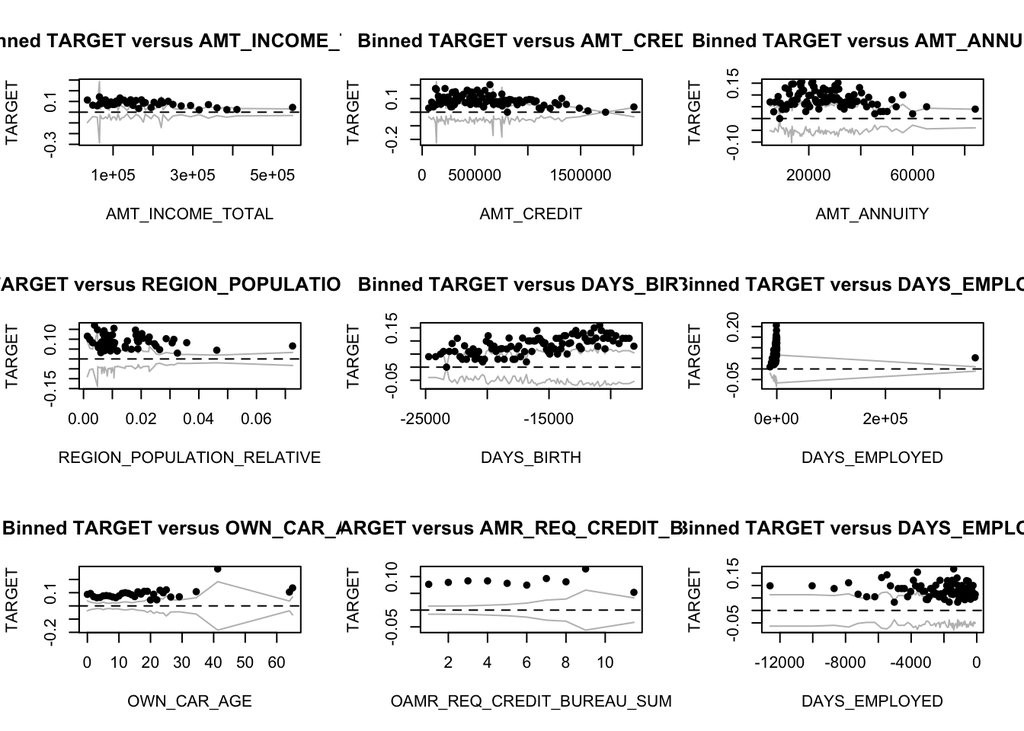

```r
par(mfrow = c(3,3))
binnedplot(x=cd1$AMT_INCOME_TOTAL, y = cd1$TARGET, xlab = "AMT_INCOME_TOTAL", ylab = "TARGET",
           main = "Binned TARGET versus AMT_INCOME_TOTAL")
binnedplot(x=cd1$AMT_CREDIT, y = cd1$TARGET, xlab = "AMT_CREDIT", ylab = "TARGET",
           main = "Binned TARGET versus AMT_CREDIT")
binnedplot(x=cd1$AMT_ANNUITY, y = cd1$TARGET, xlab = "AMT_ANNUITY", ylab = "TARGET",
           main = "Binned TARGET versus AMT_ANNUITY")
binnedplot(x=cd1$REGION_POPULATION_RELATIVE , y = cd1$TARGET, xlab = "REGION_POPULATION_RELATIVE", ylab = "TARGET",
           main = "Binned TARGET versus REGION_POPULATION_RELATIVE")
binnedplot(x=cd1$DAYS_BIRTH , y = cd1$TARGET, xlab = "DAYS_BIRTH", ylab = "TARGET",
           main = "Binned TARGET versus DAYS_BIRTH")
binnedplot(x=cd1$DAYS_EMPLOYED , y = cd1$TARGET, xlab = "DAYS_EMPLOYED", ylab = "TARGET",
           main = "Binned TARGET versus DAYS_EMPLOYED")
binnedplot(x=cd1$OWN_CAR_AGE , y = cd1$TARGET, xlab = "OWN_CAR_AGE", ylab = "TARGET",
           main = "Binned TARGET versus OWN_CAR_AGE")
binnedplot(x=as.numeric(cd1$AMR_REQ_CREDIT_BUREAU_SUM) , y = cd1$TARGET, xlab = "OAMR_REQ_CREDIT_BUREAU_SUM", ylab = "TARGET", main = "Binned TARGET versus AMR_REQ_CREDIT_BUREAU_SUM")

temp <- cd1[cd1$DAYS_EMPLOYED != 365243,]
binnedplot(x=temp$DAYS_EMPLOYED , y = cd1$TARGET, xlab = "DAYS_EMPLOYED", ylab = "TARGET",
           main = "Binned TARGET versus DAYS_EMPLOYED")
```

## Base Regression Model

Here I constructed a base logsitic regression model without any transformation and interaction term. I also selected three complete datasets to see AUCs for the fitted models. The AUCs are fairly good at 0.6981, 0.6993 and 0.6986.

```r
reg <- with(data = application_MI, glm(TARGET ~ CODE_GENDER + NAME_CONTRACT_TYPE + AMT_INCOME_TOTAL + FLAG_OWN_CAR + FLAG_OWN_REALTY + AMT_CREDIT + AMT_ANNUITY + NAME_TYPE_SUITE + NAME_INCOME_TYPE + NAME_EDUCATION_TYPE + NAME_FAMILY_STATUS + NAME_HOUSING_TYPE + REGION_POPULATION_RELATIVE + DAYS_BIRTH + DAYS_EMPLOYED + OWN_CAR_AGE + OCCUPATION_TYPE + CNT_FAM_MEMBERS + ORGANIZATION_TYPE + AMR_REQ_CREDIT_BUREAU_SUM), family = binomial)
```

###### Use Three Completed Datasets to See AUCs for the Fitted Models

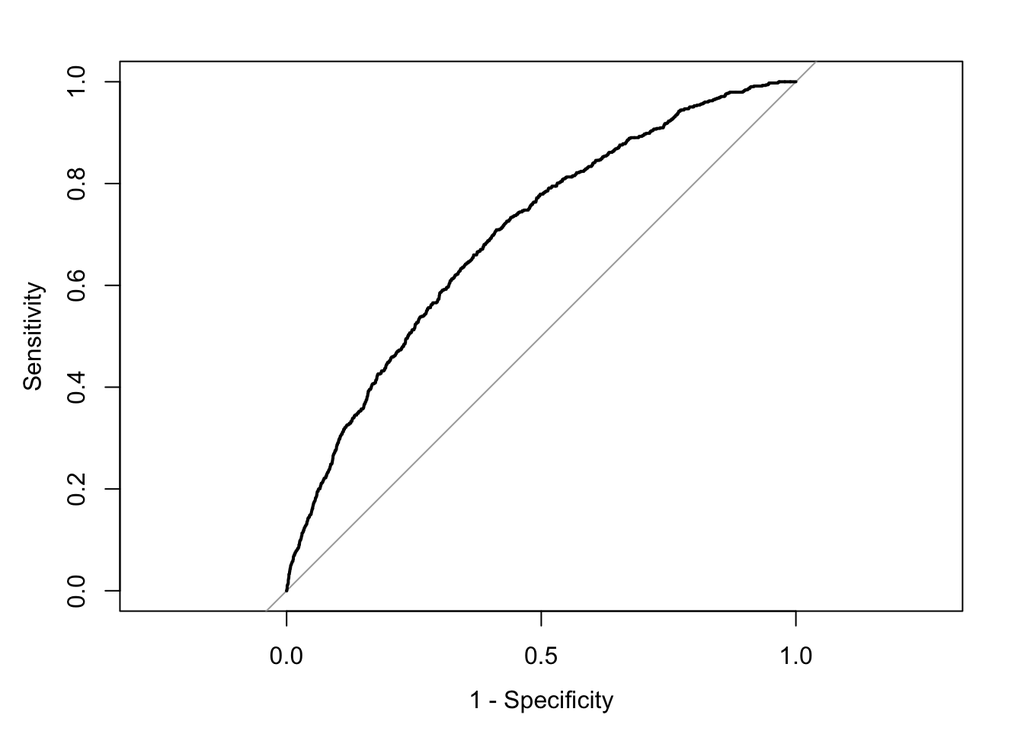

```
##
## Call:
## roc.default(response = cd1$TARGET, predictor = fitted(reg_cd1),     plot = T, legacy.axes = T)
##
## Data: fitted(reg_cd1) in 9171 controls (cd1$TARGET 0) < 829 cases (cd1$TARGET 1).
## Area under the curve: 0.6981
```

```r
#Dataset 1
par(mfrow=c(1,1))
cd1 <- mice::complete(application_MI, 1)
reg_cd1 <- glm(data=cd1, TARGET~CODE_GENDER + NAME_CONTRACT_TYPE + AMT_INCOME_TOTAL + FLAG_OWN_CAR + FLAG_OWN_REALTY + AMT_CREDIT + AMT_ANNUITY + NAME_TYPE_SUITE + NAME_INCOME_TYPE + NAME_EDUCATION_TYPE + NAME_FAMILY_STATUS + NAME_HOUSING_TYPE + REGION_POPULATION_RELATIVE + DAYS_BIRTH + DAYS_EMPLOYED + OWN_CAR_AGE + OCCUPATION_TYPE + CNT_FAM_MEMBERS + ORGANIZATION_TYPE + AMR_REQ_CREDIT_BUREAU_SUM, family=binomial)
roc(cd1$TARGET, fitted(reg_cd1), plot=T, legacy.axes=T)
```

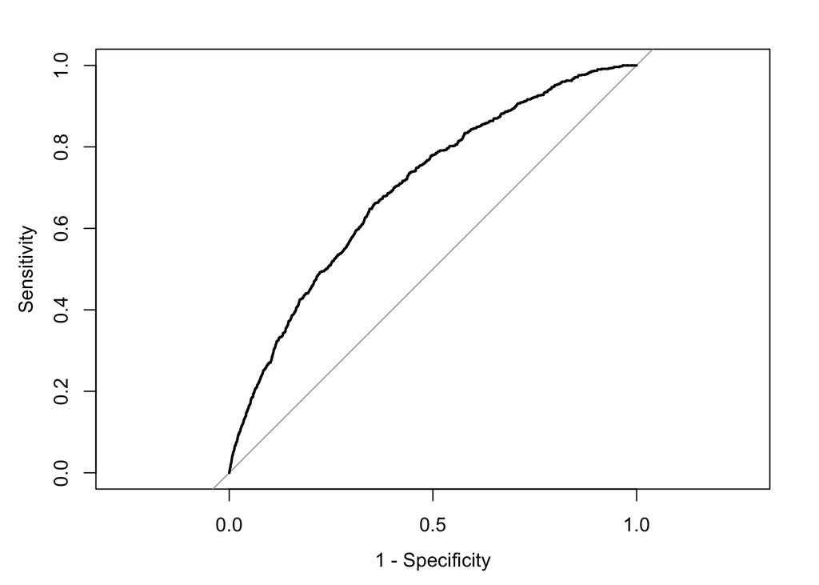

```
##
## Call:
## roc.default(response = cd2$TARGET, predictor = fitted(reg_cd2),     plot = T, legacy.axes = T)
##
## Data: fitted(reg_cd2) in 9171 controls (cd2$TARGET 0) < 829 cases (cd2$TARGET 1).
## Area under the curve: 0.6993
```

```r
#Dataset 2
cd2 <- mice::complete(application_MI, 2)
reg_cd2 <- glm(data=cd2, TARGET~CODE_GENDER + NAME_CONTRACT_TYPE + AMT_INCOME_TOTAL + FLAG_OWN_CAR + FLAG_OWN_REALTY + AMT_CREDIT + AMT_ANNUITY + NAME_TYPE_SUITE + NAME_INCOME_TYPE + NAME_EDUCATION_TYPE + NAME_FAMILY_STATUS + NAME_HOUSING_TYPE + REGION_POPULATION_RELATIVE + DAYS_BIRTH + DAYS_EMPLOYED + OWN_CAR_AGE + OCCUPATION_TYPE + CNT_FAM_MEMBERS + ORGANIZATION_TYPE + AMR_REQ_CREDIT_BUREAU_SUM,  family=binomial)
roc(cd2$TARGET, fitted(reg_cd2), plot=T, legacy.axes=T)
```

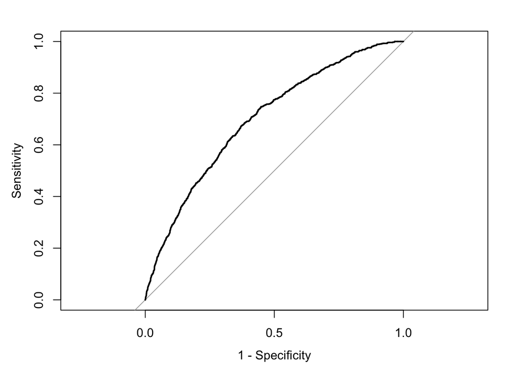

```
##
## Call:
## roc.default(response = cd3$TARGET, predictor = fitted(reg_cd3),     plot = T, legacy.axes = T)
##
## Data: fitted(reg_cd3) in 9171 controls (cd3$TARGET 0) < 829 cases (cd3$TARGET 1).
## Area under the curve: 0.6986
```

```r
#Dataset 3
cd3 <- mice::complete(application_MI, 3)
reg_cd3 <- glm(data=cd3, TARGET~CODE_GENDER + NAME_CONTRACT_TYPE + AMT_INCOME_TOTAL + FLAG_OWN_CAR + FLAG_OWN_REALTY + AMT_CREDIT + AMT_ANNUITY
               + NAME_TYPE_SUITE + NAME_INCOME_TYPE + NAME_EDUCATION_TYPE + NAME_FAMILY_STATUS + NAME_HOUSING_TYPE
               + REGION_POPULATION_RELATIVE + DAYS_BIRTH + DAYS_EMPLOYED + OWN_CAR_AGE + OCCUPATION_TYPE + CNT_FAM_MEMBERS
               + ORGANIZATION_TYPE + AMR_REQ_CREDIT_BUREAU_SUM,
               family=binomial)
roc(cd3$TARGET, fitted(reg_cd3), plot=T, legacy.axes=T)
```

## Model Diagnostics

For continuous variables:

I used binned plots to check residuals to check validity of model assumptions for continuous variables. Based on plots below, there’s no major violation of model assumptions, except for *Binned residuals versus DAYS_EMPLOYED*. The plot is largely skewed by some points. Therefore, I plotted another residual plot to investigate if the other points form any pattern that might violate model assumptions.

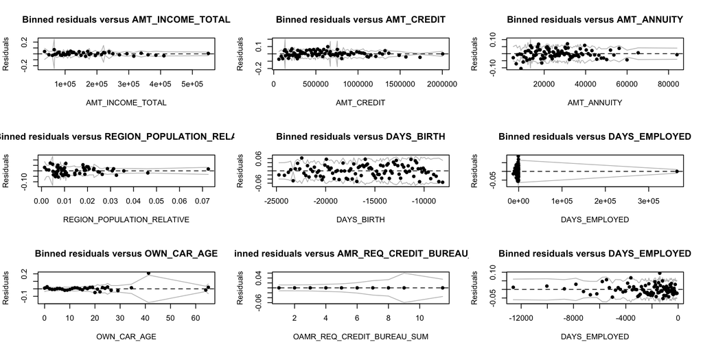

```r
par(mfrow = c(3,3))
#Dataset 1
cd1 <- mice::complete(application_MI, 1)
#Binned residual plots
rawresid1 = cd1$TARGET - fitted(reg_cd1)
#continuous variables
binnedplot(x=cd1$AMT_INCOME_TOTAL, y = rawresid1, xlab = "AMT_INCOME_TOTAL", ylab = "Residuals",
           main = "Binned residuals versus AMT_INCOME_TOTAL")
binnedplot(x=cd1$AMT_CREDIT, y = rawresid1, xlab = "AMT_CREDIT", ylab = "Residuals",
           main = "Binned residuals versus AMT_CREDIT")
binnedplot(x=cd1$AMT_ANNUITY, y = rawresid1, xlab = "AMT_ANNUITY", ylab = "Residuals",
           main = "Binned residuals versus AMT_ANNUITY")
binnedplot(x=cd1$REGION_POPULATION_RELATIVE , y = rawresid1, xlab = "REGION_POPULATION_RELATIVE", ylab = "Residuals",
           main = "Binned residuals versus REGION_POPULATION_RELATIVE")
binnedplot(x=cd1$DAYS_BIRTH , y = rawresid1, xlab = "DAYS_BIRTH", ylab = "Residuals",
           main = "Binned residuals versus DAYS_BIRTH")
binnedplot(x=cd1$DAYS_EMPLOYED , y = rawresid1, xlab = "DAYS_EMPLOYED", ylab = "Residuals",
           main = "Binned residuals versus DAYS_EMPLOYED")
binnedplot(x=cd1$OWN_CAR_AGE , y = rawresid1, xlab = "OWN_CAR_AGE", ylab = "Residuals",
           main = "Binned residuals versus OWN_CAR_AGE")
binnedplot(x=as.numeric(cd1$AMR_REQ_CREDIT_BUREAU_SUM) , y = rawresid1, xlab = "OAMR_REQ_CREDIT_BUREAU_SUM", ylab = "Residuals", main = "Binned residuals versus AMR_REQ_CREDIT_BUREAU_SUM")

#DAYS_EMPLOYED
temp <- cd1[cd1$DAYS_EMPLOYED != 365243,]
binnedplot(x=temp$DAYS_EMPLOYED , y = rawresid1, xlab = "DAYS_EMPLOYED", ylab = "Residuals",
           main = "Binned residuals versus DAYS_EMPLOYED")
```

After I excluded the large value in the `DAYS_EMPLOYED` columns(`application_data_sam$DAYS_EMPLOYED == 365,243`), the residual plot suggests no major violation of model assumptions. For those large value outliers, as they are also valid input data, I have no scientific reason to remove them.

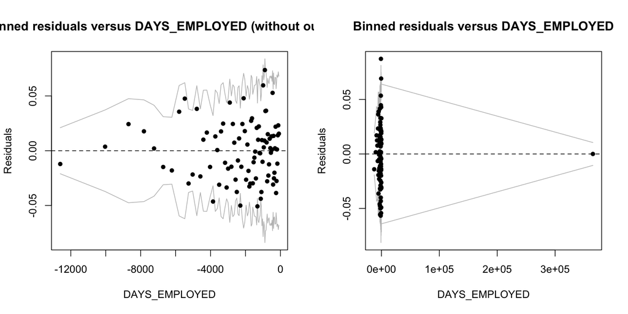

```r
par(mfrow = c(1,2))
binnedplot(x=cd1$DAYS_EMPLOYED[cd1$DAYS_EMPLOYED != max(application_data_sam$DAYS_EMPLOYED)] , y = rawresid1[cd1$DAYS_EMPLOYED != max(application_data_sam$DAYS_EMPLOYED)], xlab = "DAYS_EMPLOYED", ylab = "Residuals",
           main = "Binned residuals versus DAYS_EMPLOYED (without outliers)")
binnedplot(x=cd1$DAYS_EMPLOYED , y = rawresid1, xlab = "DAYS_EMPLOYED", ylab = "Residuals",
           main = "Binned residuals versus DAYS_EMPLOYED")
```

## Interaction Effect

There are several pairs of variables we would like to check for possible interaction effects based on the scientific reasons underneath.

- `NAME_INCOME_TYPE` versus `AMT_CREDIT` The amount of credit a client has is typically based on his income type in the financial practice. For example, state servants’ incomes are considered more stable and banks typically give them higher amounts of credits. Therefore, I believe there could be an interaction effect between these two variables. However, after taking an F-test, we could conclude that the interaction effect is not significant and I should not incorporate it into my model.

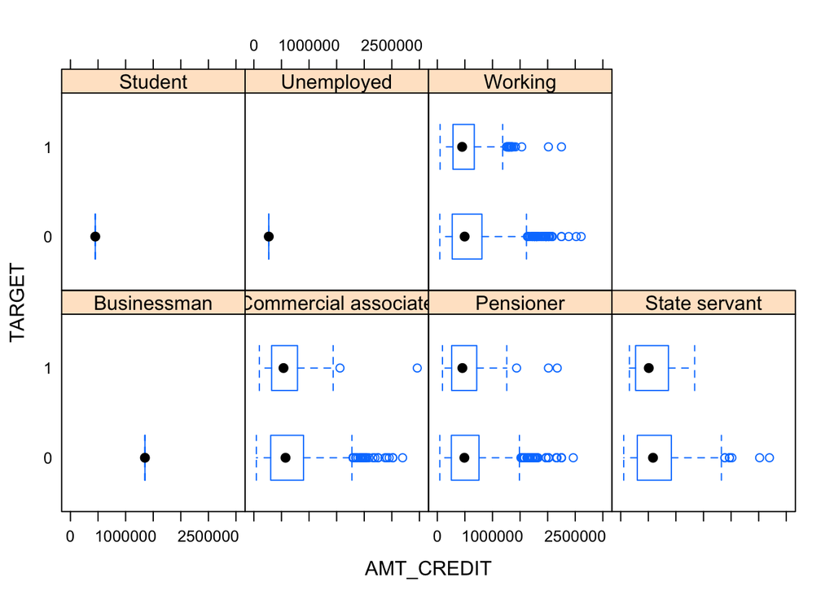

```r
bwplot(as.factor(TARGET)~AMT_CREDIT|as.factor(NAME_INCOME_TYPE), data = cd1, ylab = "TARGET")
```

```r
reg_cd1 <- glm(data=cd1, TARGET~CODE_GENDER + NAME_CONTRACT_TYPE + AMT_INCOME_TOTAL + FLAG_OWN_CAR + FLAG_OWN_REALTY + AMT_CREDIT + AMT_ANNUITY + NAME_TYPE_SUITE + NAME_INCOME_TYPE + NAME_EDUCATION_TYPE + NAME_FAMILY_STATUS + NAME_HOUSING_TYPE + REGION_POPULATION_RELATIVE + DAYS_BIRTH + DAYS_EMPLOYED + OWN_CAR_AGE + OCCUPATION_TYPE + CNT_FAM_MEMBERS + ORGANIZATION_TYPE + AMR_REQ_CREDIT_BUREAU_SUM, family=binomial)
reg_int <- glm(data=cd1, TARGET~CODE_GENDER + NAME_CONTRACT_TYPE + AMT_INCOME_TOTAL + FLAG_OWN_CAR + FLAG_OWN_REALTY + AMT_CREDIT + AMT_ANNUITY + NAME_TYPE_SUITE + NAME_INCOME_TYPE + NAME_EDUCATION_TYPE + NAME_FAMILY_STATUS + NAME_HOUSING_TYPE + REGION_POPULATION_RELATIVE + DAYS_BIRTH + DAYS_EMPLOYED + OWN_CAR_AGE + OCCUPATION_TYPE + CNT_FAM_MEMBERS + ORGANIZATION_TYPE + AMR_REQ_CREDIT_BUREAU_SUM + AMT_CREDIT*NAME_INCOME_TYPE, family=binomial)
anova(reg_cd1, reg_int, test = "Chisq")
```

```
## Analysis of Deviance Table
##
## Model 1: TARGET ~ CODE_GENDER + NAME_CONTRACT_TYPE + AMT_INCOME_TOTAL +
##     FLAG_OWN_CAR + FLAG_OWN_REALTY + AMT_CREDIT + AMT_ANNUITY +
##     NAME_TYPE_SUITE + NAME_INCOME_TYPE + NAME_EDUCATION_TYPE +
##     NAME_FAMILY_STATUS + NAME_HOUSING_TYPE + REGION_POPULATION_RELATIVE +
##     DAYS_BIRTH + DAYS_EMPLOYED + OWN_CAR_AGE + OCCUPATION_TYPE +
##     CNT_FAM_MEMBERS + ORGANIZATION_TYPE + AMR_REQ_CREDIT_BUREAU_SUM
## Model 2: TARGET ~ CODE_GENDER + NAME_CONTRACT_TYPE + AMT_INCOME_TOTAL +
##     FLAG_OWN_CAR + FLAG_OWN_REALTY + AMT_CREDIT + AMT_ANNUITY +
##     NAME_TYPE_SUITE + NAME_INCOME_TYPE + NAME_EDUCATION_TYPE +
##     NAME_FAMILY_STATUS + NAME_HOUSING_TYPE + REGION_POPULATION_RELATIVE +
##     DAYS_BIRTH + DAYS_EMPLOYED + OWN_CAR_AGE + OCCUPATION_TYPE +
##     CNT_FAM_MEMBERS + ORGANIZATION_TYPE + AMR_REQ_CREDIT_BUREAU_SUM +
##     AMT_CREDIT * NAME_INCOME_TYPE
##   Resid. Df Resid. Dev Df Deviance Pr(>Chi)
## 1      9863     5318.2
## 2      9860     5316.5  3   1.6452   0.6492
```

- `NAME_EDUCATION_TYPE` versus `AMT_INCOME_TOTAL` The amount of income is typically associated with the highest education he or her received. Therefore, I try to see if there’s any interaction effect between these two variables. The plots below suggest that there might be an interaction effect, though not very clear. But the F-test indicates that I should not add an interaction term between these two variables in the regression model.

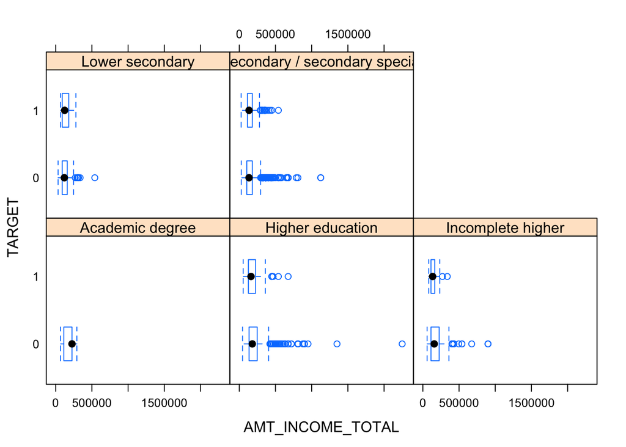

```r
bwplot(as.factor(TARGET)~AMT_INCOME_TOTAL|as.factor(NAME_EDUCATION_TYPE), data = cd1, ylab = "TARGET")
```

```r
reg_cd1 <- glm(data=cd1, TARGET~CODE_GENDER + NAME_CONTRACT_TYPE + AMT_INCOME_TOTAL + FLAG_OWN_CAR + FLAG_OWN_REALTY + AMT_CREDIT + AMT_ANNUITY + NAME_TYPE_SUITE + NAME_INCOME_TYPE + NAME_EDUCATION_TYPE + NAME_FAMILY_STATUS + NAME_HOUSING_TYPE + REGION_POPULATION_RELATIVE + DAYS_BIRTH + DAYS_EMPLOYED + OWN_CAR_AGE + OCCUPATION_TYPE + CNT_FAM_MEMBERS + ORGANIZATION_TYPE + AMR_REQ_CREDIT_BUREAU_SUM, family=binomial)
reg_int <- glm(data=cd1, TARGET~CODE_GENDER + NAME_CONTRACT_TYPE + AMT_INCOME_TOTAL + FLAG_OWN_CAR + FLAG_OWN_REALTY + AMT_CREDIT + AMT_ANNUITY + NAME_TYPE_SUITE + NAME_INCOME_TYPE + NAME_EDUCATION_TYPE + NAME_FAMILY_STATUS + NAME_HOUSING_TYPE + REGION_POPULATION_RELATIVE + DAYS_BIRTH + DAYS_EMPLOYED + OWN_CAR_AGE + OCCUPATION_TYPE + CNT_FAM_MEMBERS + ORGANIZATION_TYPE + AMR_REQ_CREDIT_BUREAU_SUM + AMT_INCOME_TOTAL*NAME_EDUCATION_TYPE, family=binomial)
anova(reg_cd1, reg_int, test = "Chisq")
```

```
## Analysis of Deviance Table
##
## Model 1: TARGET ~ CODE_GENDER + NAME_CONTRACT_TYPE + AMT_INCOME_TOTAL +
##     FLAG_OWN_CAR + FLAG_OWN_REALTY + AMT_CREDIT + AMT_ANNUITY +
##     NAME_TYPE_SUITE + NAME_INCOME_TYPE + NAME_EDUCATION_TYPE +
##     NAME_FAMILY_STATUS + NAME_HOUSING_TYPE + REGION_POPULATION_RELATIVE +
##     DAYS_BIRTH + DAYS_EMPLOYED + OWN_CAR_AGE + OCCUPATION_TYPE +
##     CNT_FAM_MEMBERS + ORGANIZATION_TYPE + AMR_REQ_CREDIT_BUREAU_SUM
## Model 2: TARGET ~ CODE_GENDER + NAME_CONTRACT_TYPE + AMT_INCOME_TOTAL +
##     FLAG_OWN_CAR + FLAG_OWN_REALTY + AMT_CREDIT + AMT_ANNUITY +
##     NAME_TYPE_SUITE + NAME_INCOME_TYPE + NAME_EDUCATION_TYPE +
##     NAME_FAMILY_STATUS + NAME_HOUSING_TYPE + REGION_POPULATION_RELATIVE +
##     DAYS_BIRTH + DAYS_EMPLOYED + OWN_CAR_AGE + OCCUPATION_TYPE +
##     CNT_FAM_MEMBERS + ORGANIZATION_TYPE + AMR_REQ_CREDIT_BUREAU_SUM +
##     AMT_INCOME_TOTAL * NAME_EDUCATION_TYPE
##   Resid. Df Resid. Dev Df Deviance Pr(>Chi)
## 1      9863     5318.2
## 2      9859     5314.8  4   3.4027   0.4928
```

- `OCCUPATION_TYPE` versus `AMT_INCOME_TOTAL` Different kinds of occupation generally have different levels of incomes. For example, high skill tech staffs typically have higher incomes than cleaning staffs. Hence, I think there might be an interaction effect. However, the F-test suggests that the interaction effect is not significant enough and I should not add it into the model.

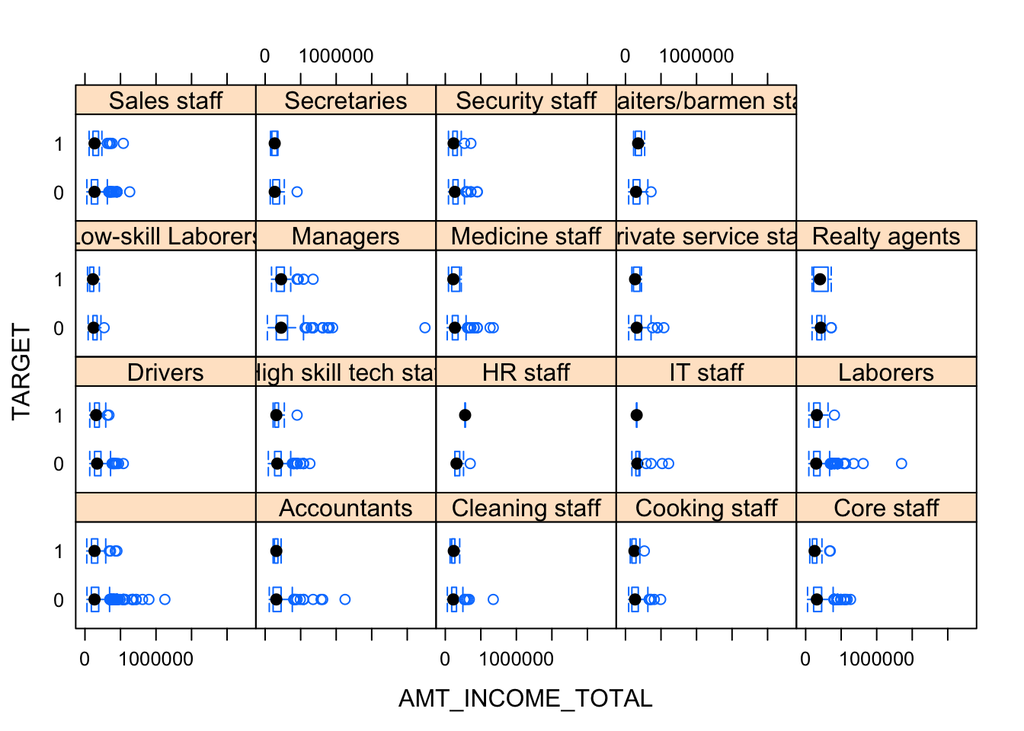

```r
bwplot(as.factor(TARGET)~AMT_INCOME_TOTAL|as.factor(OCCUPATION_TYPE), data = cd1, ylab = "TARGET")
```

```r
reg_cd1 <- glm(data=cd1, TARGET~CODE_GENDER + NAME_CONTRACT_TYPE + AMT_INCOME_TOTAL + FLAG_OWN_CAR + FLAG_OWN_REALTY + AMT_CREDIT + AMT_ANNUITY + NAME_TYPE_SUITE + NAME_INCOME_TYPE + NAME_EDUCATION_TYPE + NAME_FAMILY_STATUS + NAME_HOUSING_TYPE + REGION_POPULATION_RELATIVE + DAYS_BIRTH + DAYS_EMPLOYED + OWN_CAR_AGE + OCCUPATION_TYPE + CNT_FAM_MEMBERS + ORGANIZATION_TYPE + AMR_REQ_CREDIT_BUREAU_SUM, family=binomial)
reg_int <- glm(data=cd1, TARGET~CODE_GENDER + NAME_CONTRACT_TYPE + AMT_INCOME_TOTAL + FLAG_OWN_CAR + FLAG_OWN_REALTY + AMT_CREDIT + AMT_ANNUITY + NAME_TYPE_SUITE + NAME_INCOME_TYPE + NAME_EDUCATION_TYPE + NAME_FAMILY_STATUS + NAME_HOUSING_TYPE + REGION_POPULATION_RELATIVE + DAYS_BIRTH + DAYS_EMPLOYED + OWN_CAR_AGE + OCCUPATION_TYPE + CNT_FAM_MEMBERS + ORGANIZATION_TYPE + AMR_REQ_CREDIT_BUREAU_SUM + AMT_INCOME_TOTAL*OCCUPATION_TYPE, family=binomial)
anova(reg_cd1, reg_int, test = "Chisq")
```

```
## Analysis of Deviance Table
##
## Model 1: TARGET ~ CODE_GENDER + NAME_CONTRACT_TYPE + AMT_INCOME_TOTAL +
##     FLAG_OWN_CAR + FLAG_OWN_REALTY + AMT_CREDIT + AMT_ANNUITY +
##     NAME_TYPE_SUITE + NAME_INCOME_TYPE + NAME_EDUCATION_TYPE +
##     NAME_FAMILY_STATUS + NAME_HOUSING_TYPE + REGION_POPULATION_RELATIVE +
##     DAYS_BIRTH + DAYS_EMPLOYED + OWN_CAR_AGE + OCCUPATION_TYPE +
##     CNT_FAM_MEMBERS + ORGANIZATION_TYPE + AMR_REQ_CREDIT_BUREAU_SUM
## Model 2: TARGET ~ CODE_GENDER + NAME_CONTRACT_TYPE + AMT_INCOME_TOTAL +
##     FLAG_OWN_CAR + FLAG_OWN_REALTY + AMT_CREDIT + AMT_ANNUITY +
##     NAME_TYPE_SUITE + NAME_INCOME_TYPE + NAME_EDUCATION_TYPE +
##     NAME_FAMILY_STATUS + NAME_HOUSING_TYPE + REGION_POPULATION_RELATIVE +
##     DAYS_BIRTH + DAYS_EMPLOYED + OWN_CAR_AGE + OCCUPATION_TYPE +
##     CNT_FAM_MEMBERS + ORGANIZATION_TYPE + AMR_REQ_CREDIT_BUREAU_SUM +
##     AMT_INCOME_TOTAL * OCCUPATION_TYPE
##   Resid. Df Resid. Dev Df Deviance Pr(>Chi)
## 1      9863     5318.2
## 2      9845     5294.4 18   23.756   0.1632
```

- `ORGANIZATION_TYPE` versus `AMT_CREDIT` For most banks’ practices, banks generally offer different credit amounts for people work in different organizations. For example, most banks offer Fortune 500 companies’ employees more credits. As a result, we think there might be an interaction effect between these two variables. The plots below also suggests that there could be a potential interaction term to be added. However, the F-test indicates that the interaction term is not significant enough to be added into the regression model.

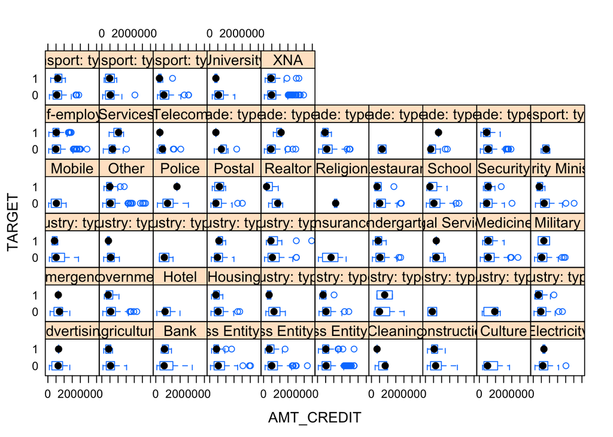

```r
bwplot(as.factor(TARGET)~AMT_CREDIT|as.factor(ORGANIZATION_TYPE), data = cd1, ylab = "TARGET")
```

```r
reg_cd1 <- glm(data=cd1, TARGET~CODE_GENDER + NAME_CONTRACT_TYPE + AMT_INCOME_TOTAL + FLAG_OWN_CAR + FLAG_OWN_REALTY + AMT_CREDIT + AMT_ANNUITY + NAME_TYPE_SUITE + NAME_INCOME_TYPE + NAME_EDUCATION_TYPE + NAME_FAMILY_STATUS + NAME_HOUSING_TYPE + REGION_POPULATION_RELATIVE + DAYS_BIRTH + DAYS_EMPLOYED + OWN_CAR_AGE + OCCUPATION_TYPE + CNT_FAM_MEMBERS + ORGANIZATION_TYPE + AMR_REQ_CREDIT_BUREAU_SUM, family=binomial)
reg_int <- glm(data=cd1, TARGET~CODE_GENDER + NAME_CONTRACT_TYPE + AMT_INCOME_TOTAL + FLAG_OWN_CAR + FLAG_OWN_REALTY + AMT_CREDIT + AMT_ANNUITY + NAME_TYPE_SUITE + NAME_INCOME_TYPE + NAME_EDUCATION_TYPE + NAME_FAMILY_STATUS + NAME_HOUSING_TYPE + REGION_POPULATION_RELATIVE + DAYS_BIRTH + DAYS_EMPLOYED + OWN_CAR_AGE + OCCUPATION_TYPE + CNT_FAM_MEMBERS + ORGANIZATION_TYPE + AMR_REQ_CREDIT_BUREAU_SUM + AMT_CREDIT*ORGANIZATION_TYPE, family=binomial)
anova(reg_cd1, reg_int, test = "Chisq")
```

```
## Analysis of Deviance Table
##
## Model 1: TARGET ~ CODE_GENDER + NAME_CONTRACT_TYPE + AMT_INCOME_TOTAL +
##     FLAG_OWN_CAR + FLAG_OWN_REALTY + AMT_CREDIT + AMT_ANNUITY +
##     NAME_TYPE_SUITE + NAME_INCOME_TYPE + NAME_EDUCATION_TYPE +
##     NAME_FAMILY_STATUS + NAME_HOUSING_TYPE + REGION_POPULATION_RELATIVE +
##     DAYS_BIRTH + DAYS_EMPLOYED + OWN_CAR_AGE + OCCUPATION_TYPE +
##     CNT_FAM_MEMBERS + ORGANIZATION_TYPE + AMR_REQ_CREDIT_BUREAU_SUM
## Model 2: TARGET ~ CODE_GENDER + NAME_CONTRACT_TYPE + AMT_INCOME_TOTAL +
##     FLAG_OWN_CAR + FLAG_OWN_REALTY + AMT_CREDIT + AMT_ANNUITY +
##     NAME_TYPE_SUITE + NAME_INCOME_TYPE + NAME_EDUCATION_TYPE +
##     NAME_FAMILY_STATUS + NAME_HOUSING_TYPE + REGION_POPULATION_RELATIVE +
##     DAYS_BIRTH + DAYS_EMPLOYED + OWN_CAR_AGE + OCCUPATION_TYPE +
##     CNT_FAM_MEMBERS + ORGANIZATION_TYPE + AMR_REQ_CREDIT_BUREAU_SUM +
##     AMT_CREDIT * ORGANIZATION_TYPE
##   Resid. Df Resid. Dev Df Deviance Pr(>Chi)
## 1      9863     5318.2
## 2      9809     5276.7 54   41.466   0.8942
```

# Model Interpretation

After examining all the possible pairs of variables that could have interaction effects; furthermore, there’s no evidence suggests a logarithm or quadratic transformation on variables, therefore, the base model should be our ultimate model.

Significant predictors: - CODE_GENDERM - NAME_CONTRACT_TYPERevolving loans - FLAG_OWN_CARY - DAYS_BIRTH - DAYS_EMPLOYED - OCCUPATION_TYPEWaiters/barmen staff - CNT_FAM_MEMBERS6 - ORGANIZATION_TYPERealtor - ORGANIZATION_TYPEXNA - AMR_REQ_CREDIT_BUREAU_SUM8

```r
summary(pool(reg))
```

```
##                                                       estimate
## (Intercept)                                       2.063259e-01
## CODE_GENDERM                                      4.352771e-02
## NAME_CONTRACT_TYPERevolving loans                -5.055284e-02
## AMT_INCOME_TOTAL                                 -5.315301e-08
## FLAG_OWN_CARY                                    -3.081047e-02
## FLAG_OWN_REALTYY                                  5.206398e-03
## AMT_CREDIT                                       -1.320492e-08
## AMT_ANNUITY                                      -1.769943e-07
## NAME_TYPE_SUITEChildren                          -2.756176e-02
## NAME_TYPE_SUITEFamily                            -9.752861e-03
## NAME_TYPE_SUITEGroup of people                   -1.140243e-01
## NAME_TYPE_SUITEOther_A                           -6.362593e-02
## NAME_TYPE_SUITEOther_B                           -6.131117e-02
## NAME_TYPE_SUITESpouse, partner                   -9.428628e-03
## NAME_TYPE_SUITEUnaccompanied                     -1.514317e-02
## NAME_INCOME_TYPECommercial associate             -1.027763e-01
## NAME_INCOME_TYPEPensioner                        -1.580174e-01
## NAME_INCOME_TYPEState servant                    -1.063998e-01
## NAME_INCOME_TYPEStudent                          -9.719079e-02
## NAME_INCOME_TYPEUnemployed                       -2.097608e-01
## NAME_INCOME_TYPEWorking                          -8.310605e-02
## NAME_EDUCATION_TYPEHigher education               3.705344e-02
## NAME_EDUCATION_TYPEIncomplete higher              5.441029e-02
## NAME_EDUCATION_TYPELower secondary                7.767959e-02
## NAME_EDUCATION_TYPESecondary / secondary special  5.559630e-02
## NAME_FAMILY_STATUSMarried                        -6.035944e-03
## NAME_FAMILY_STATUSSeparated                      -1.670707e-03
## NAME_FAMILY_STATUSSingle / not married            7.999912e-03
## NAME_FAMILY_STATUSWidow                           1.727822e-02
## NAME_HOUSING_TYPEHouse / apartment                5.891942e-03
## NAME_HOUSING_TYPEMunicipal apartment             -2.051035e-03
## NAME_HOUSING_TYPEOffice apartment                -4.512994e-02
## NAME_HOUSING_TYPERented apartment                 3.482144e-02
## NAME_HOUSING_TYPEWith parents                     2.526804e-02
## REGION_POPULATION_RELATIVE                       -9.805655e-02
## DAYS_BIRTH                                        3.216099e-06
## DAYS_EMPLOYED                                     6.241027e-06
## OWN_CAR_AGE                                       1.037233e-04
## OCCUPATION_TYPEAccountants                       -1.463772e-02
```

[output cut: 359 more lines]

```
## AMR_REQ_CREDIT_BUREAU_SUM7                        521.47606 4.028441e-01
## AMR_REQ_CREDIT_BUREAU_SUM8                        302.47679 3.295141e-02
## AMR_REQ_CREDIT_BUREAU_SUM9                        276.96744 6.392286e-01
## AMR_REQ_CREDIT_BUREAU_SUM10                      6861.17223 6.789695e-01
## AMR_REQ_CREDIT_BUREAU_SUM11                      1787.91692 9.652245e-01
## AMR_REQ_CREDIT_BUREAU_SUM12                      9659.66009 6.953321e-01
## AMR_REQ_CREDIT_BUREAU_SUM13                      9710.15537 5.256008e-01
## AMR_REQ_CREDIT_BUREAU_SUM14                      9819.14406 9.226638e-01
## AMR_REQ_CREDIT_BUREAU_SUM15                      9501.72835 5.299607e-01
## AMR_REQ_CREDIT_BUREAU_SUM16                      9859.90649 9.196110e-01
## AMR_REQ_CREDIT_BUREAU_SUM17                      9859.35814 7.155472e-01
## AMR_REQ_CREDIT_BUREAU_SUM18                      9491.65927 6.899178e-01
## AMR_REQ_CREDIT_BUREAU_SUM19                      9859.90649 9.511950e-01
## AMR_REQ_CREDIT_BUREAU_SUM20                      9858.65550 8.435467e-01
## AMR_REQ_CREDIT_BUREAU_SUM28                      9833.27900 6.672155e-01
```

```r
summary(pool(reg), conf.int=T)
```

```
##                                                       estimate
## (Intercept)                                       2.063259e-01
## CODE_GENDERM                                      4.352771e-02
## NAME_CONTRACT_TYPERevolving loans                -5.055284e-02
## AMT_INCOME_TOTAL                                 -5.315301e-08
## FLAG_OWN_CARY                                    -3.081047e-02
## FLAG_OWN_REALTYY                                  5.206398e-03
## AMT_CREDIT                                       -1.320492e-08
## AMT_ANNUITY                                      -1.769943e-07
## NAME_TYPE_SUITEChildren                          -2.756176e-02
## NAME_TYPE_SUITEFamily                            -9.752861e-03
## NAME_TYPE_SUITEGroup of people                   -1.140243e-01
## NAME_TYPE_SUITEOther_A                           -6.362593e-02
## NAME_TYPE_SUITEOther_B                           -6.131117e-02
## NAME_TYPE_SUITESpouse, partner                   -9.428628e-03
## NAME_TYPE_SUITEUnaccompanied                     -1.514317e-02
## NAME_INCOME_TYPECommercial associate             -1.027763e-01
## NAME_INCOME_TYPEPensioner                        -1.580174e-01
## NAME_INCOME_TYPEState servant                    -1.063998e-01
## NAME_INCOME_TYPEStudent                          -9.719079e-02
## NAME_INCOME_TYPEUnemployed                       -2.097608e-01
## NAME_INCOME_TYPEWorking                          -8.310605e-02
## NAME_EDUCATION_TYPEHigher education               3.705344e-02
## NAME_EDUCATION_TYPEIncomplete higher              5.441029e-02
## NAME_EDUCATION_TYPELower secondary                7.767959e-02
## NAME_EDUCATION_TYPESecondary / secondary special  5.559630e-02
## NAME_FAMILY_STATUSMarried                        -6.035944e-03
## NAME_FAMILY_STATUSSeparated                      -1.670707e-03
## NAME_FAMILY_STATUSSingle / not married            7.999912e-03
## NAME_FAMILY_STATUSWidow                           1.727822e-02
## NAME_HOUSING_TYPEHouse / apartment                5.891942e-03
## NAME_HOUSING_TYPEMunicipal apartment             -2.051035e-03
## NAME_HOUSING_TYPEOffice apartment                -4.512994e-02
## NAME_HOUSING_TYPERented apartment                 3.482144e-02
## NAME_HOUSING_TYPEWith parents                     2.526804e-02
## REGION_POPULATION_RELATIVE                       -9.805655e-02
## DAYS_BIRTH                                        3.216099e-06
## DAYS_EMPLOYED                                     6.241027e-06
## OWN_CAR_AGE                                       1.037233e-04
## OCCUPATION_TYPEAccountants                       -1.463772e-02
```

[output cut: 635 more lines]

```
## AMR_REQ_CREDIT_BUREAU_SUM7                        5.317304e-02
## AMR_REQ_CREDIT_BUREAU_SUM8                        1.123533e-01
## AMR_REQ_CREDIT_BUREAU_SUM9                        8.795301e-02
## AMR_REQ_CREDIT_BUREAU_SUM10                       6.909664e-02
## AMR_REQ_CREDIT_BUREAU_SUM11                       1.404227e-01
## AMR_REQ_CREDIT_BUREAU_SUM12                       1.658377e-01
## AMR_REQ_CREDIT_BUREAU_SUM13                       1.533711e-01
## AMR_REQ_CREDIT_BUREAU_SUM14                       3.352075e-01
## AMR_REQ_CREDIT_BUREAU_SUM15                       1.760994e-01
## AMR_REQ_CREDIT_BUREAU_SUM16                       5.099801e-01
## AMR_REQ_CREDIT_BUREAU_SUM17                       4.351645e-01
## AMR_REQ_CREDIT_BUREAU_SUM18                       2.872795e-01
## AMR_REQ_CREDIT_BUREAU_SUM19                       5.215201e-01
## AMR_REQ_CREDIT_BUREAU_SUM20                       4.516868e-01
## AMR_REQ_CREDIT_BUREAU_SUM28                       3.977509e-01
```

## Model Limitation

The limitation of this logistic regressino model includes the following: - I cannot do extrapolation for prediction that is our of the range that I use to form the logistic regression model. - The predictability of this model is relatively week as most p-values are quite large. - The predictability is subject to the choice of threshold.